# Data Visualisation with ggplot2 - Project

## 3. External Data Source Validation

The data is originally from the article Hotel Booking Demand Datasets, by Nuno Antonio, Ana Almeida, and Luis Nunes for Data in Brief, Volume 22, February 2019.

## 4. Data Preparation

### Performing Data Cleaning

```r
# Checking datatypes and missing entries of all the variables
# ---
# YOUR CODE GOES BELOW
#
sum(is.na(hotel_bookings))
```

```
[1] 4
```

```r
# Checking how many duplicate rows are there in the data
# ---
# YOUR CODE GOES BELOW
#
sum(duplicated(hotel_bookings))
```

```
[1] 31994
```

We choose to keep the duplicates because we don’t have a unique identifier to actually proof that we have duplicates.

```r
# Checking if any of the columns are all null
# ---
# YOUR CODE GOES BELOW
#

empty_columns <- colSums(is.na(hotel_bookings)) == nrow(hotel_bookings)

empty_columns
```

```
                         hotel                    is_canceled                      lead_time
                         FALSE                          FALSE                          FALSE
             arrival_date_year             arrival_date_month       arrival_date_week_number
                         FALSE                          FALSE                          FALSE
     arrival_date_day_of_month        stays_in_weekend_nights           stays_in_week_nights
                         FALSE                          FALSE                          FALSE
                        adults                       children                         babies
                         FALSE                          FALSE                          FALSE
                          meal                        country                 market_segment
                         FALSE                          FALSE                          FALSE
          distribution_channel              is_repeated_guest         previous_cancellations
                         FALSE                          FALSE                          FALSE
previous_bookings_not_canceled             reserved_room_type             assigned_room_type
                         FALSE                          FALSE                          FALSE
               booking_changes                   deposit_type                          agent
                         FALSE                          FALSE                          FALSE
                       company           days_in_waiting_list                  customer_type
                         FALSE                          FALSE                          FALSE
                           adr    required_car_parking_spaces      total_of_special_requests
                         FALSE                          FALSE                          FALSE
            reservation_status        reservation_status_date
                         FALSE                          FALSE
```

We observe the following from our dataset:

Observation: No empty columns observed

```r
# Checking if any of the rows are all null
# ---
# YOUR CODE GOES BELOW
#

empty_rows <- rowSums(is.na(hotel_bookings)) == ncol(hotel_bookings)

empty_rows
```

```
   [1] FALSE FALSE FALSE FALSE FALSE FALSE FALSE FALSE FALSE FALSE FALSE FALSE FALSE FALSE FALSE FALSE FALSE FALSE
  [19] FALSE FALSE FALSE FALSE FALSE FALSE FALSE FALSE FALSE FALSE FALSE FALSE FALSE FALSE FALSE FALSE FALSE FALSE
  [37] FALSE FALSE FALSE FALSE FALSE FALSE FALSE FALSE FALSE FALSE FALSE FALSE FALSE FALSE FALSE FALSE FALSE FALSE
  [55] FALSE FALSE FALSE FALSE FALSE FALSE FALSE FALSE FALSE FALSE FALSE FALSE FALSE FALSE FALSE FALSE FALSE FALSE
  [73] FALSE FALSE FALSE FALSE FALSE FALSE FALSE FALSE FALSE FALSE FALSE FALSE FALSE FALSE FALSE FALSE FALSE FALSE
  [91] FALSE FALSE FALSE FALSE FALSE FALSE FALSE FALSE FALSE FALSE FALSE FALSE FALSE FALSE FALSE FALSE FALSE FALSE
 [109] FALSE FALSE FALSE FALSE FALSE FALSE FALSE FALSE FALSE FALSE FALSE FALSE FALSE FALSE FALSE FALSE FALSE FALSE
 [127] FALSE FALSE FALSE FALSE FALSE FALSE FALSE FALSE FALSE FALSE FALSE FALSE FALSE FALSE FALSE FALSE FALSE FALSE
 [145] FALSE FALSE FALSE FALSE FALSE FALSE FALSE FALSE FALSE FALSE FALSE FALSE FALSE FALSE FALSE FALSE FALSE FALSE
 [163] FALSE FALSE FALSE FALSE FALSE FALSE FALSE FALSE FALSE FALSE FALSE FALSE FALSE FALSE FALSE FALSE FALSE FALSE
 [181] FALSE FALSE FALSE FALSE FALSE FALSE FALSE FALSE FALSE FALSE FALSE FALSE FALSE FALSE FALSE FALSE FALSE FALSE
 [199] FALSE FALSE FALSE FALSE FALSE FALSE FALSE FALSE FALSE FALSE FALSE FALSE FALSE FALSE FALSE FALSE FALSE FALSE
 [217] FALSE FALSE FALSE FALSE FALSE FALSE FALSE FALSE FALSE FALSE FALSE FALSE FALSE FALSE FALSE FALSE FALSE FALSE
 [235] FALSE FALSE FALSE FALSE FALSE FALSE FALSE FALSE FALSE FALSE FALSE FALSE FALSE FALSE FALSE FALSE FALSE FALSE
 [253] FALSE FALSE FALSE FALSE FALSE FALSE FALSE FALSE FALSE FALSE FALSE FALSE FALSE FALSE FALSE FALSE FALSE FALSE
```

[output cut: 42 more lines]

```r
# Checking the correlation of the features through the use of
# visualizations the correlation using heatmap
# ---
# YOUR CODE GOES BELOW
#

# Prepare Corr Matrix
corr_matrix <- cor(hotel_bookings[sapply(hotel_bookings,is.numeric)])
head(corr_matrix)
```

```
                           is_canceled   lead_time arrival_date_year arrival_date_week_number
is_canceled                1.000000000 0.293123356      0.0166598602              0.008148065
lead_time                  0.293123356 1.000000000      0.0401420998              0.126870813
arrival_date_year          0.016659860 0.040142100      1.0000000000             -0.540561331
arrival_date_week_number   0.008148065 0.126870813     -0.5405613308              1.000000000
arrival_date_day_of_month -0.006130079 0.002267553     -0.0002210192              0.066809253
stays_in_weekend_nights   -0.001791078 0.085671133      0.0214973654              0.018207653
                          arrival_date_day_of_month stays_in_weekend_nights stays_in_week_nights       adults
is_canceled                           -0.0061300789            -0.001791078           0.02476463  0.060017213
lead_time                              0.0022675527             0.085671133           0.16579936  0.119518693
arrival_date_year                     -0.0002210192             0.021497365           0.03088330  0.029635144
arrival_date_week_number               0.0668092530             0.018207653           0.01555830  0.025909057
arrival_date_day_of_month              1.0000000000            -0.016354300          -0.02817352 -0.001565979
stays_in_weekend_nights               -0.0163542995             1.000000000           0.49896882  0.091871020
                          children        babies is_repeated_guest previous_cancellations
is_canceled                     NA -0.0324910892      -0.084793418             0.11013281
lead_time                       NA -0.0209150163      -0.124409908             0.08604180
arrival_date_year               NA -0.0131920747       0.010341317            -0.11982207
arrival_date_week_number        NA  0.0103954801      -0.030130758             0.03550091
arrival_date_day_of_month       NA -0.0002303647      -0.006145021            -0.02701078
stays_in_weekend_nights         NA  0.0184828105      -0.087239379            -0.01277462
                          previous_bookings_not_canceled booking_changes days_in_waiting_list         adr
is_canceled                                -0.0573577232   -0.1443809911           0.05418582  0.04755660
lead_time                                  -0.0735481679    0.0001488301           0.17008418 -0.06307685
arrival_date_year                           0.0292180512    0.0308723496          -0.05649660  0.19758009
arrival_date_week_number                   -0.0209035517    0.0055075035           0.02293303  0.07579064
arrival_date_day_of_month                  -0.0002997868    0.0106128560           0.02272754  0.03024519
stays_in_weekend_nights                    -0.0427152350    0.0632813159          -0.05415111  0.04934191
                          required_car_parking_spaces total_of_special_requests
is_canceled                              -0.195497817              -0.234657774
lead_time                                -0.116450570              -0.095712049
arrival_date_year                        -0.013684411               0.108531486
arrival_date_week_number                  0.001920423               0.026149364
arrival_date_day_of_month                 0.008683466               0.003062124
stays_in_weekend_nights                  -0.018553809               0.072670830
```

```r
library(ggplot2)
# Create a table with long form
corr_df <- melt(corr_matrix)
head(corr_df)
```

|  | X1 | X2 | value |
| --- | --- | --- | --- |
| 1 | is_canceled | is_canceled | 1.000000000 |
| 2 | lead_time | is_canceled | 0.293123356 |
| 3 | arrival_date_year | is_canceled | 0.016659860 |
| 4 | arrival_date_week_number | is_canceled | 0.008148065 |
| 5 | arrival_date_day_of_month | is_canceled | -0.006130079 |
| 6 | stays_in_weekend_nights | is_canceled | -0.001791078 |

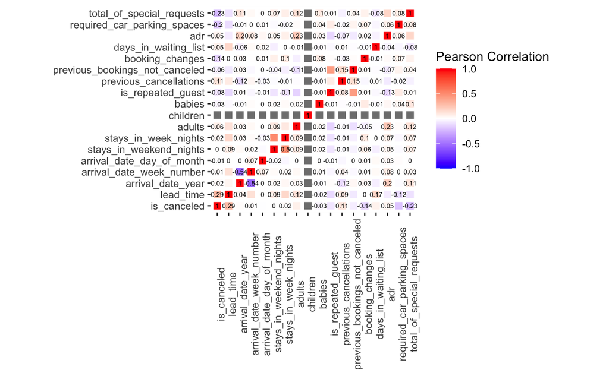

```r
ggplot(corr_df, aes(X1, X2, fill = value)) +
  geom_tile(color = "white",
            lwd = 1.5,
            linetype = 1) +
  geom_text(
    aes(label = round(value, 2)),
    color = "black",
    check_overlap =  TRUE,
    size = 2

  ) +
  coord_fixed() +
  labs(
    fill="Pearson Correlation"
  ) +
  scale_fill_gradient2(
    low = "blue",
    high = "red",
    mid = "white",
    limit = c(-1,1)
  ) +
  theme(
    axis.text.x = element_text(angle = 90),
    axis.title.x = element_blank(),
    axis.title.y = element_blank()
  )
```

We observe the following from our dataset:

Observation 1 : arrival_date_year and arrival_date_week_number are negatively correlated.  
Observation 2 : stays_in_week_nights and stays_in_weekend_nights are positively correlated.

```r
# Dropping company column because it has alot of missing values
# and we won't need to answer any of our questions
# ---
# YOUR CODE GOES BELOW
#
df <- hotel_bookings %>%
  select(-c(company))

str(df)
```

```
tibble [119,390 × 31] (S3: tbl_df/tbl/data.frame)
 $ hotel                         : chr [1:119390] "Resort Hotel" "Resort Hotel" "Resort Hotel" "Resort Hotel" ...
 $ is_canceled                   : num [1:119390] 0 0 0 0 0 0 0 0 1 1 ...
 $ lead_time                     : num [1:119390] 342 737 7 13 14 14 0 9 85 75 ...
 $ arrival_date_year             : num [1:119390] 2015 2015 2015 2015 2015 ...
 $ arrival_date_month            : chr [1:119390] "July" "July" "July" "July" ...
 $ arrival_date_week_number      : num [1:119390] 27 27 27 27 27 27 27 27 27 27 ...
 $ arrival_date_day_of_month     : num [1:119390] 1 1 1 1 1 1 1 1 1 1 ...
 $ stays_in_weekend_nights       : num [1:119390] 0 0 0 0 0 0 0 0 0 0 ...
 $ stays_in_week_nights          : num [1:119390] 0 0 1 1 2 2 2 2 3 3 ...
 $ adults                        : num [1:119390] 2 2 1 1 2 2 2 2 2 2 ...
 $ children                      : num [1:119390] 0 0 0 0 0 0 0 0 0 0 ...
 $ babies                        : num [1:119390] 0 0 0 0 0 0 0 0 0 0 ...
 $ meal                          : chr [1:119390] "BB" "BB" "BB" "BB" ...
 $ country                       : chr [1:119390] "PRT" "PRT" "GBR" "GBR" ...
```

[output cut: 17 more lines]

From the data variable description we see that the Distribution Channel categoricy that tells us about Booking distribution.

```r
# We replace the mising values i.e. for TO
# ---
# YOUR GOES BELOW
#

df$distribution_channel[is.na(df$distribution_channel)] <- "TO"
```

```r
# We drop rows where there is no adult, baby and child as
# these records won't help us.
# ---
# YOUR GOES BELOW
#
final_df <- df %>%
  filter(adults!=0 | babies !=0 |  children !=0)
```

```r
# We replace missing children values with rounded mean value
# ---
# Hint i.e. use round()
# ---
# YOUR GOES BELOW
#
Mean <- round(mean(final_df$children,na.rm =TRUE),1)

final_df$children[is.na(final_df$children)] <- Mean
```

```r
# Checking for missing values in the dataframe
# ---
# YOUR GOES BELOW
#
sum(is.na(final_df))
```

```
[1] 0
```

```r
# Converting the datatypes of the following columns from float to integer
# i.e. children, company, agent
# ---
# YOUR GOES BELOW
#

final_df$children <- as.integer(final_df$children)
final_df$agent <- as.integer(final_df$agent)
str(final_df)
```

```
tibble [119,210 × 31] (S3: tbl_df/tbl/data.frame)
 $ hotel                         : chr [1:119210] "Resort Hotel" "Resort Hotel" "Resort Hotel" "Resort Hotel" ...
 $ is_canceled                   : num [1:119210] 0 0 0 0 0 0 0 0 1 1 ...
 $ lead_time                     : num [1:119210] 342 737 7 13 14 14 0 9 85 75 ...
 $ arrival_date_year             : num [1:119210] 2015 2015 2015 2015 2015 ...
 $ arrival_date_month            : chr [1:119210] "July" "July" "July" "July" ...
 $ arrival_date_week_number      : num [1:119210] 27 27 27 27 27 27 27 27 27 27 ...
 $ arrival_date_day_of_month     : num [1:119210] 1 1 1 1 1 1 1 1 1 1 ...
 $ stays_in_weekend_nights       : num [1:119210] 0 0 0 0 0 0 0 0 0 0 ...
 $ stays_in_week_nights          : num [1:119210] 0 0 1 1 2 2 2 2 3 3 ...
 $ adults                        : num [1:119210] 2 2 1 1 2 2 2 2 2 2 ...
 $ children                      : int [1:119210] 0 0 0 0 0 0 0 0 0 0 ...
 $ babies                        : num [1:119210] 0 0 0 0 0 0 0 0 0 0 ...
 $ meal                          : chr [1:119210] "BB" "BB" "BB" "BB" ...
 $ country                       : chr [1:119210] "PRT" "PRT" "GBR" "GBR" ...
```

[output cut: 17 more lines]